# Capstone: Random Forest

Andrew Knittle

Generated on 2021-07-31

# Method

## Background: Decision Trees

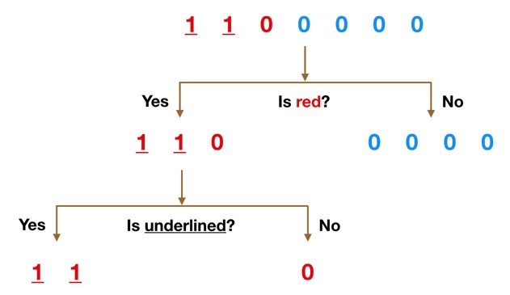

Before reading this section it would be worth while to read on the report on *Conditional Decision Trees* I wrote because this report builds on that. You can also read this [blog post that explains both Conditional Decision Trees and Random Forest, as I quote from it quite a bit myself](https://towardsdatascience.com/understanding-random-forest-58381e0602d2) In short Decision Trees separate different features of data at nodes for classification (if “red” take left path, if “blue” take right path). A Tree usually consists of several branches where each leads to “another tree”; these are recursive structures that contain same pattern repeated until some edge case in the form of a leaf node.

## Random Forests

Random Forests take Decision Trees and make well a “forest” of them. Each individual tree in the forest returns a classification result (A or B) and the result with the most votes is what the forest predicts classification as. For example if a forest of 10 trees is used to classify something as *Red* or *Blue*, and 7 trees returned *Blue* then the forest would return *Blue*. The results get democratized!

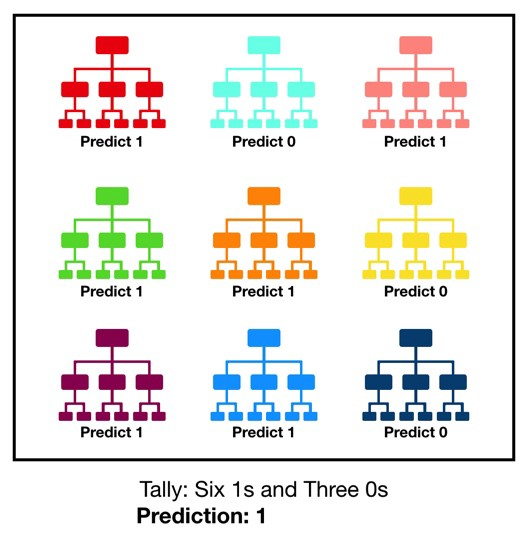

Random Forests work when a [“large number of relatively uncorrelated models (trees) operating as a committee will outperform any of the individual constituent models.”](https://towardsdatascience.com/understanding-random-forest-58381e0602d2) The most important part of a forest working well is that each tree has low correlation between other trees. You can think of each tree as a juror, you want a diverse set of people as jurors because together as collection should cancel out any other juror’s bias; the last thing you want in a fair trial is a jury that is rigged!

For a good performing tree it needs to follow two criteria:

- 1: [There needs to be some actual signal in our features so that models built using those features do better than random guessing.](https://towardsdatascience.com/understanding-random-forest-58381e0602d2)
- 2: [The predictions (and therefore the errors) made by the individual trees need to have low correlations with each other.](https://towardsdatascience.com/understanding-random-forest-58381e0602d2)

### Diverse Trees

In order to make a forest diverse, in other words making sure each tree has low correlation with each other, we can use two well used options: **Bagging (Bootstrap Aggregation)** or **Feature Randomness**.

#### Bagging

Each tree samples with replacement.

#### Feature Randomness

Some get some features and others don’t.

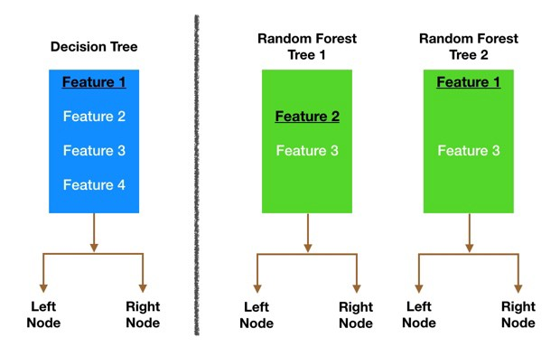

# Performance

[I recommend reading this blog post for the intricate details and how to make your own Random Forest in R](https://www.blopig.com/blog/2017/04/a-very-basic-introduction-to-random-forests-using-r/)

| Avg. Training Error | Avg. Validation Error |
| --- | --- |
| 0.4387513 | 0.4483051 |

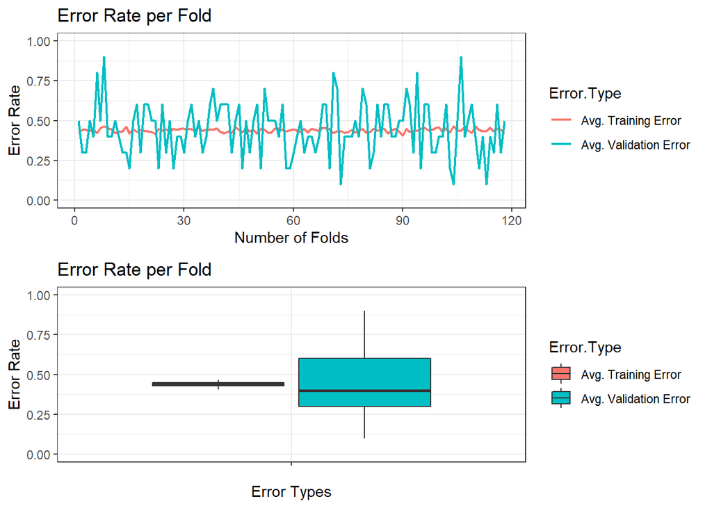

Model Building 1

|  | Observed NO | Observed YES |
| --- | --- | --- |
| Predicted NO | 147 | 168 |
| Predicted YES | 361 | 504 |

| Error Rate | False Positive Rate (Fall-Out) | False Negative Rate (Miss Rate) | True Positive Rate (Sensitivity) | True Negative Rate (Specificity) | Precision (PPV) | Negative Predictive Value (NPV) |
| --- | --- | --- | --- | --- | --- | --- |
| 0.4483051 | 0.7106299 | 0.25 | 0.75 | 0.2893701 | 0.582659 | 0.4666667 |